# Lecture 17

Filtering observations with `filter()`; Arrange observations with `arrange()`

Byeong-Hak Choe

bchoe@geneseo.edu

SUNY Geneseo

April 4, 2024

## Data Transformation

- Because the first argument is a `data.frame` and the output is a `data.frame`, `dplyr` verbs work well with the **pipe**, `|>`
  - **Ctrl + Shift + M** for Windows; **command + Shift + M** for Mac.
- The **pipe** (`|>`) takes the thing on its left and passes it along to the function on its right so that
  - `f(x, y)` is equivalent to `x |> f(y)`.
  - e.g., `filter(DATA_FRAME, LOGICAL_STATEMENT)` is equivalent to `DATA_FRAME |> filter(LOGICAL_STATEMENT)`.
- The easiest way to pronounce the **pipe** (`|>`) is “**then**”.
  - The **pipe** (`|>`) is super useful when we have *a chain of data transforming operations* to do.

## Data Transformation

- To use the (native) pipe operator (`|>`), we should set the option as follows:
  - **Tools** > **Global Options** > **Code** from the side menu > Choose “Use native pipe operator, |>”.

## Data Transformation

### `dplyr` basics

- `DATA_FRAME |> filter(LOGICAL_CONDITIONS)`
- `DATA_FRAME |> arrange(VARIABLES)`
- `DATA_FRAME |> select(VARIABLES)`
- `DATA_FRAME |> rename(NEW_VARIABLE = EXISTING_VARIABLE)`
- `DATA_FRAME |> mutate(NEW_VARIABLE = ... )`
- `DATA_FRAME |> relocate(VARIABLES)`
- `DATA_FRAME |> group_by(VARIABLES)`
- `DATA_FRAME |> summarize(NEW_VARIABLE = ...)`
- The subsequent arguments describe what to do with the data.frame, mostly using the variable names.
- The result is a **data.frame**.

# Filter observations with `filter()`

## Filter observations with `filter()`

```r
jan1 <- flights |>
  filter(month == 1, day == 1)

dec25 <- flights |>
  filter(month == 12, day == 25)

class(flights$month == 1)
```

- `filter()` allows us to subset observations based on the value of logical conditions, which are either `TRUE` or `FALSE`.

## Filter observations with `filter()`

### Logicals and Conditions

| Operator | Description |
| --- | --- |
| x &amp; y | Are x and y both TRUE? |
| x \| y | Is at least one of x and y TRUE? |
| !x | Is x FALSE? |

- Logical variables have either `TRUE` or `FALSE` value.
- Conditions are expressions that evaluate as `logical`
- What logical operations do is combining logical conditions, which returns a logical value when executed.

## Filter observations with `filter()`

### `logical` conditions

| Operator | Description |
| --- | --- |
| x == y | Is x equal to y? |
| x != y | Is x not equal to y? |
| x &gt; y | Is x greater than y? |
| x &gt;= y | Is x greater than or equal to y? |
| x &lt; y | Is x less than y? |
| x &lt;= y | Is x less than or equal to y? |

## Filter observations with `filter()`

### Boolean Operations

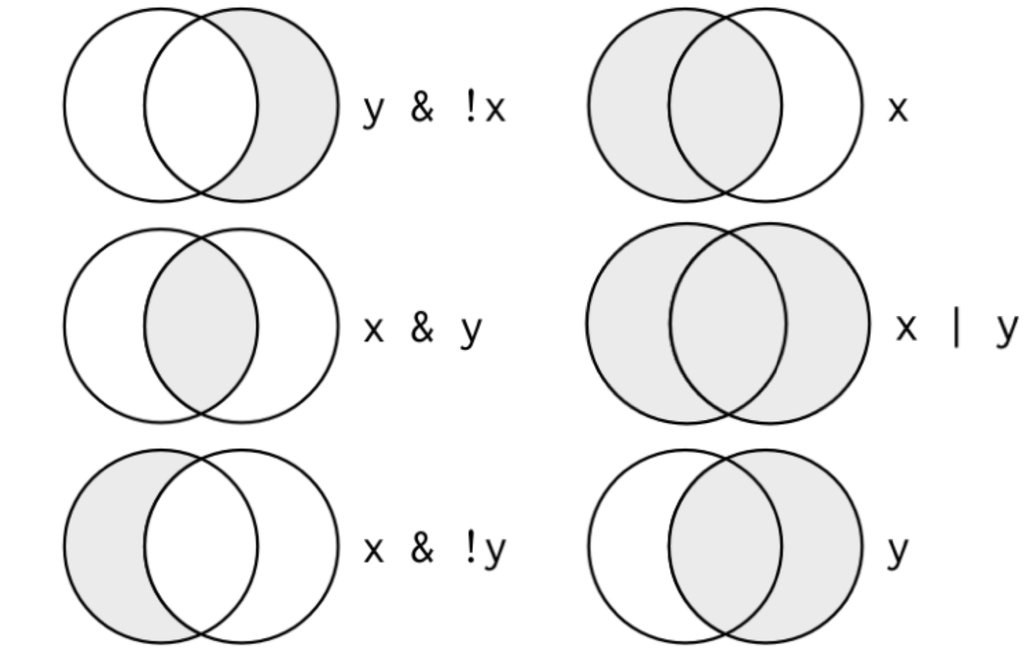

- `x` is the left-hand circle, `y` is the right-hand circle, and the shaded region show which parts each operator selects.

## Filter observations with `filter()`

### `logical` conditions

```r
df <- data.frame(
  num = c(8, 9, 10, 11),
  chr = c("A", "C", "B", "A"))
```

| num | chr |
| --- | --- |
| 8 | A |
| 9 | C |
| 10 | B |
| 11 | A |

```r
df |> filter(num > 8 &
                num < 11)

df |> filter(num > 8,
             num < 11)
```

| num | chr |
| --- | --- |
| 9 | C |
| 10 | B |

## Filter observations with `filter()`

### `logical` conditions

```r
df <- data.frame(
  num = c(8, 9, 10, 11),
  chr = c("A", "C", "B", "A"))
```

| num | chr |
| --- | --- |
| 8 | A |
| 9 | C |
| 10 | B |
| 11 | A |

```r
df |> filter(num < 10 &
             chr == "A")

df |> filter(num < 10,
             chr == "A")
```

| num | chr |
| --- | --- |
| 8 | A |

## Filter observations with `filter()`

### `logical` conditions

```r
df <- data.frame(
  num = c(8, 9, 10, 11),
  chr = c("A", "C", "B", "A"))
```

| num | chr |
| --- | --- |
| 8 | A |
| 9 | C |
| 10 | B |
| 11 | A |

```r
df |> filter(num < 10 |
                chr == "A")
```

| num | chr |
| --- | --- |
| 8 | A |
| 9 | C |
| 11 | A |

## Filter observations with `filter()`

### De Morgan’s law

```r
flights |>
  filter( !( arr_delay > 120 |
              dep_delay > 120) )
```

```r
flights |>
  filter( arr_delay <= 120 &
            dep_delay <= 120 )
```

- `!(x & y)` is the same as `!x | !y`.
- `!(x | y)` is the same as `!x & !y`.

## Filter observations with `filter()`

### `%in%` operator

- When the **or** operator `|` is repeatedly used, we can consider using the `%in%` operator instead.

```r
flights |>
  filter( month == 10 |
            month == 11 |
            month == 12 )
```

```r
flights |>
  filter(month %in% c(10, 11, 12))
```

## Filter observations with `filter()`

### Missing values (`NA`)

- (1)
- (2)
- `is.na()`
- Almost any operation involving an unknown value (`NA`) will also be unknown.

```r
NA > 5
10 == NA
NA + 10
NA / 2

NA == NA
```

- Let `x` be Mary’s age. We don’t know how old she is.
- Let `y` be John’s age. We don’t know how old he is.
- Are John and Mary the same age?

```r
x <- NA
y <- NA
x == y
```

- If we want to determine if a value is missing, use `is.na()`.
- If we want to preserve missing values, ask `filter()` for them explicitly.

```r
x <- NA
is.na(x) # is x NA?

y <- "missing"
is.na(y) # is y NA?
```

```r
df <- data.frame(y = c(1, NA, 3))

df |>
  filter(y > 1)

df |>
  filter( is.na(y) | y > 1 )
```

# Find all unique observations with `distinct()`

## Find all unique observations with `distinct()`

```r
# Remove duplicate observations,
#  if any
flights |>
  distinct()
```

```r
# Find all unique
#  origin and destination pairs
flights |>
  distinct(origin, dest)

# If we want to keep other variables
flights |>
  distinct(origin, dest,
           .keep_all = TRUE)
```

- `distinct()` finds all the unique observations in a data.frame.
  - We can also optionally provide variable names to `distinct()`.

# Arrange observations with `arrange()`

## Arrange observations with `arrange()`

```r
flights %>%
  arrange(year, month, day)

# re-order observations by `dep_delay` in descending order.
flights %>%
  arrange([?])
```

- `arrange()` sorts out observations.
  - If we provide more than one variable name, each additional variable will be used to break ties in the values of preceding variables.
- Use `desc()` to re-order by a column in descending order.
  - Adding `-` before a numeric variable (`-NUMERIC_VARIABLE`) also works.

## Rows: `filter()`, `distinct()`, and `arrange()`

Let’s do [Classwork 9](https://bcdanl.github.io/200/danl-cw/danl-200-cw-09.html)!